# How to make plots in R using ggpubr

michail.belias@radboudumc.nl

Michail Belias

December 6, 2018

# Introduction

- In R we can use either the base R plots (difficult and ugly) or go for ggplots.
- ggplot2 package has a steap learning curve, therefore
  - We will use ggpubr
- ggpubr is a R package that helps you create basic beautiful ggplot2-based graphs.
- Helps researchers, to create easily publication-ready plots.
- Provides the possibility to add p-values and significance levels to plots.
- Makes it easy to arrange and annotate multiple plots on the same page.
- Makes it easy to change grahical parameters such as colors and labels.
- Produces a ggplot2 object…
  - Therefore, it can be further manipulated as a ggplot object

# ggpubr package

- ggpubr has more than 25 types of plots
- ggpubr has more than 60 functions to learn
- Therefore, it’s impossible to learn them all **today**

# What I want you to learn

- How to use the help file in Rstudio
  - ggpubr functions have great help file (use it)
- theme() , ggpar() are 2 important functions that provide ggplot2 flexibility
- we can store a plot in an object using “<-” or “=”
- Google is our friend
- We are also your friends… ask us

# theme() function has everything you need to make your plot awesome ( go to the help file)

```r
theme(line, rect, text, title, aspect.ratio, axis.title, axis.title.x,
  axis.title.x.top, axis.title.x.bottom, axis.title.y, axis.title.y.left,
  axis.title.y.right, axis.text, axis.text.x, axis.text.x.top,
  axis.text.x.bottom, axis.text.y, axis.text.y.left, axis.text.y.right,
  axis.ticks, axis.ticks.x, axis.ticks.x.top, axis.ticks.x.bottom, axis.ticks.y,
  axis.ticks.y.left, axis.ticks.y.right, axis.ticks.length, axis.line,
  axis.line.x, axis.line.x.top, axis.line.x.bottom, axis.line.y,
  axis.line.y.left, axis.line.y.right, legend.background, legend.margin,
  legend.spacing, legend.spacing.x, legend.spacing.y, legend.key,
  legend.key.size, legend.key.height, legend.key.width, legend.text,
  legend.text.align, legend.title, legend.title.align, legend.position,
  legend.direction, legend.justification, legend.box, legend.box.just,
  legend.box.margin, legend.box.background, legend.box.spacing,
  panel.background, panel.border, panel.spacing, panel.spacing.x,
  panel.spacing.y, panel.grid, panel.grid.major, panel.grid.minor,
  panel.grid.major.x, panel.grid.major.y, panel.grid.minor.x,
  panel.grid.minor.y, panel.ontop, plot.background, plot.title, plot.subtitle,
  plot.caption, plot.tag, plot.tag.position, plot.margin, strip.background,
  strip.background.x, strip.background.y, strip.placement, strip.text,
  strip.text.x, strip.text.y, strip.switch.pad.grid, strip.switch.pad.wrap, ...,
  complete = FALSE, validate = TRUE)
```

# A note for the gg functions we will use

- Sometimes in their help fill at end of the options you will see three dots “…”
- This implies that the function has more options
- The options of a function like theme above can be used in our gg function

# By the end of the day we will go from this

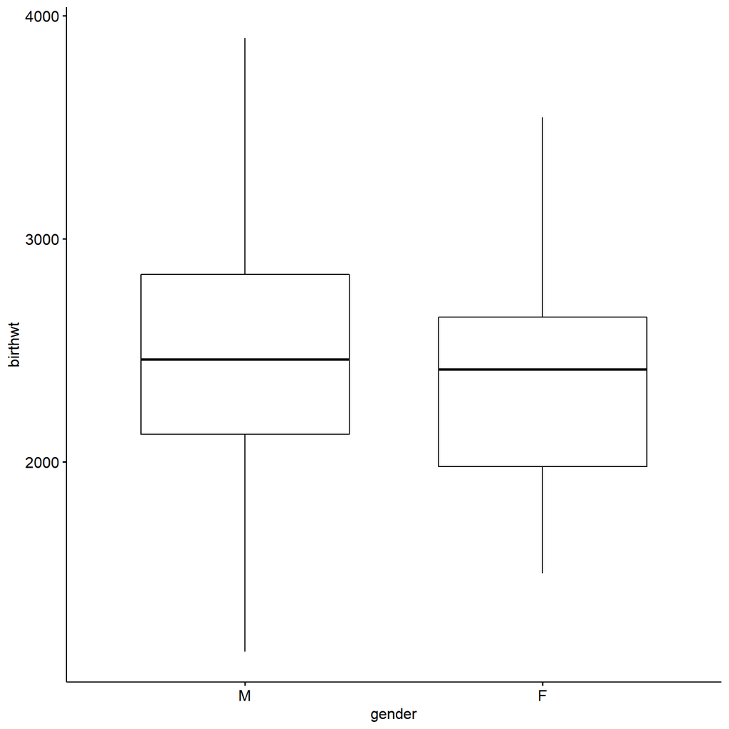

# And this

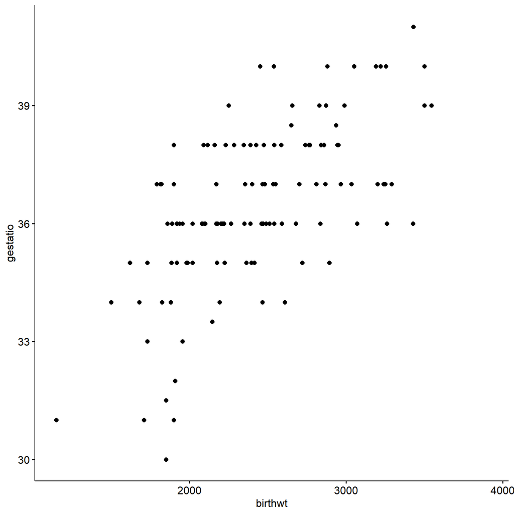

# To this

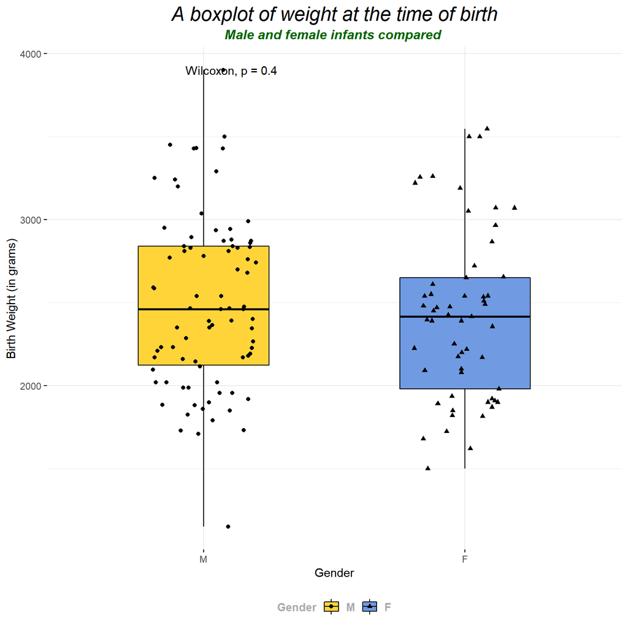

# This

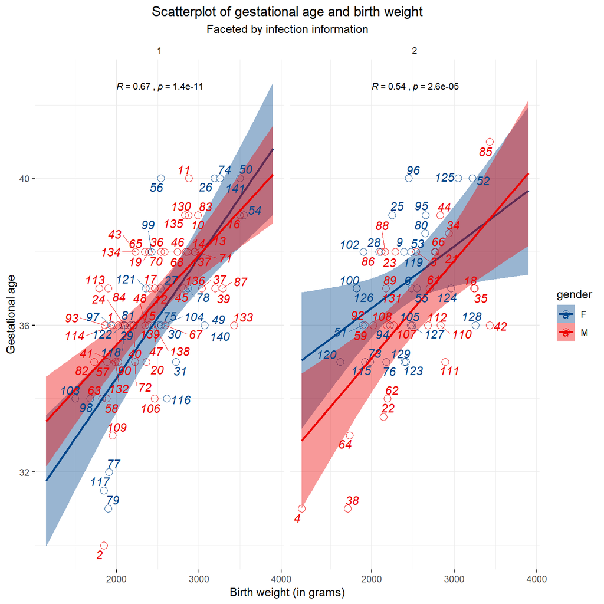

# And this

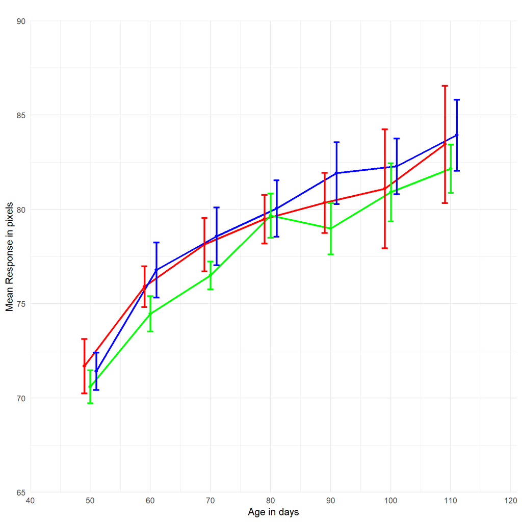

# Install and load the packages we will use

- You can do it manually through the “install” dialog in the “packages” tab
- Install the following packages
  - haven, readxl, gapminder, ggplot2, ggExtra, ggsci, dplyr, ggpubr, ggkm

# Load the data

- We can either use the command line or load them manually
- Use the “Import Dataset” dialog in the Enviroment Tab
- or the following commands

```r
library(haven)
bladder   <- read_sav("Data/bladder.sav")
surgery   <- read_sav("Data/surgery.sav")
skullrats <- read_sav("Data/SkullRats.sav")
```

# Know your data

- Feel free to use your own data in our lab
- with the following commands we can get in touch with our data
  - summary(“dataname”), names(“dataname”), head(“dataname”), view(“dataset”)
- Use the help tab in your right to see what the functions do (and their options)
- Please play around with the data

# Distribution plots

Under this section we will show how to plot

- Boxplots………..(with ggboxplot)
- Histograms………(with gghistogram)
- Density Plots……(with ggdensity)

For every function above there is a full description in their help file. Go to the tab “Help” and write the function in the search box

# Boxplot code

First we will see a simple box-plot

```r
gg<- ggboxplot(surgery ,  # the data-set
            x = "gender", # the x-values is the categorical variable
            y = "birthwt" # the y-values is their values
            )
```

# Simple boxplot

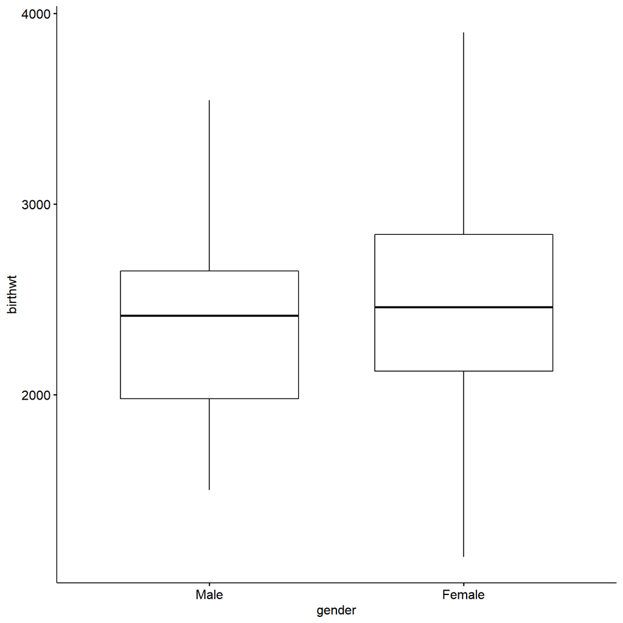

# Full boxplot code

- Search the help file of ggboxplot
- *Tip:* If you select any function and press F1 you go to the function’s help file right away

```r
ggboxplot(data, x, y, # load the data and choose the x and y variables
  combine = FALSE, merge = FALSE, color = "black",
  fill = "white", palette = NULL, title = NULL, xlab = NULL,
  ylab = NULL, bxp.errorbar = FALSE, bxp.errorbar.width = 0.4,
  facet.by = NULL, panel.labs = NULL, short.panel.labs = TRUE,
  linetype = "solid", size = NULL, width = 0.7, notch = FALSE,
  select = NULL, remove = NULL, order = NULL, add = "none",
  add.params = list(), error.plot = "pointrange", label = NULL,
  font.label = list(size = 11, color = "black"), label.select = NULL,
  repel = FALSE, label.rectangle = FALSE, ggtheme = theme_pubr())
```

# Sophisticated boxplot example code

```r
gg <- ggboxplot(data = surgery,x =  "gender", y = "birthwt",
          xlab = "Gender", ylab = "Birth Weight (in grams)",
          width = 0.5,add = "jitter",
          shape = "gender",fill = "gender",palette = "simpsons",
          title = "A boxplot of weight at the time of birth",
          legend = "bottom",legend.title="Gender",font.legend = c(10, "bold", "darkgrey"),
          font.main = c(18, "italic", "black"),
          subtitle = "Male and female infants compared ", font.subtitle = c(12, "bold.italic", "darkgreen"),
          ggtheme = theme_minimal()
) +
  theme(plot.title = element_text(hjust = 0.5),
        plot.subtitle = element_text(hjust = 0.5)) +
  stat_compare_means(method = "wilcox.test")#  Add a p-value
```

# Sophisticated boxplot example

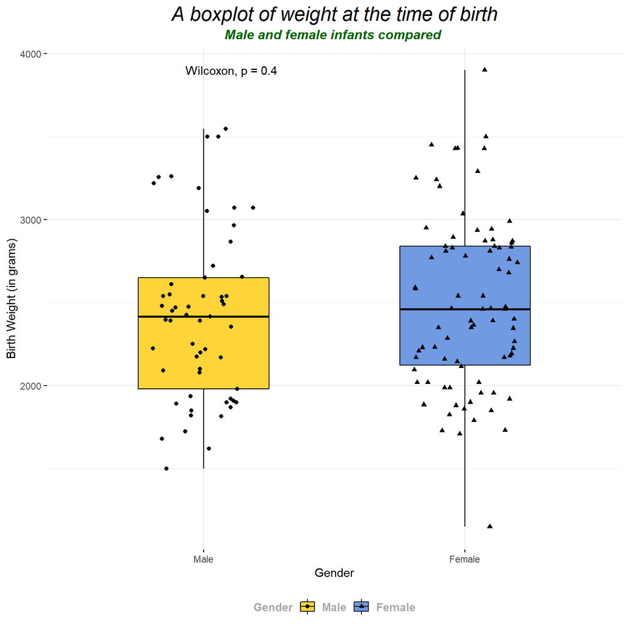

# How did we get there?

[figure not shown]

- open ggboxplot.R code

# Simple histogram code

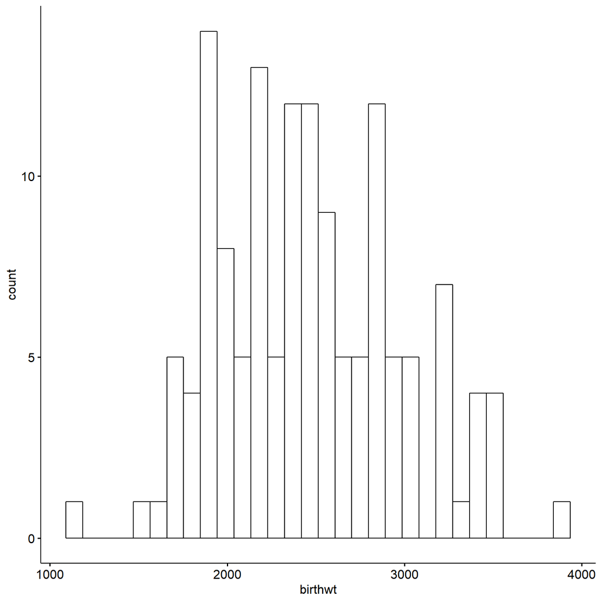

```r
# Basic histogram plot
gghistogram(surgery, x = "birthwt")
```

# Sophisticated histogram example code

```r
gg<- gghistogram(surgery, x = "birthwt",y = "..density..",add = "median",
            bins = 10 , # how many bars will the histogram have
            xlab = "Weight at birth (in grams)", ylab = "Density",
            title = "Histogram of infant weight at birth",
            fill = "gender",color = "grey",palette = "lancet",
            alpha = 0.2,legend = "bottom",legend.title="Gender",
            font.legend = c(10, "bold", "darkgrey"), facet.by = "infect", ggtheme = theme_minimal(), add_density = T )+
  theme(plot.title = element_text(hjust = 0.5),
        plot.subtitle = element_text(hjust = 0.5))
```

# Sophisticated histogram plot

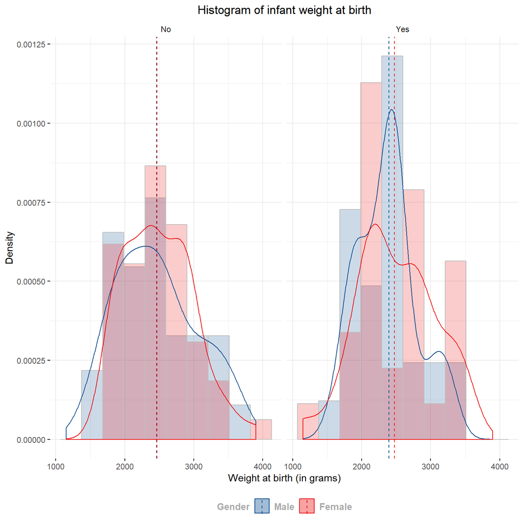

# Simple Density plot code

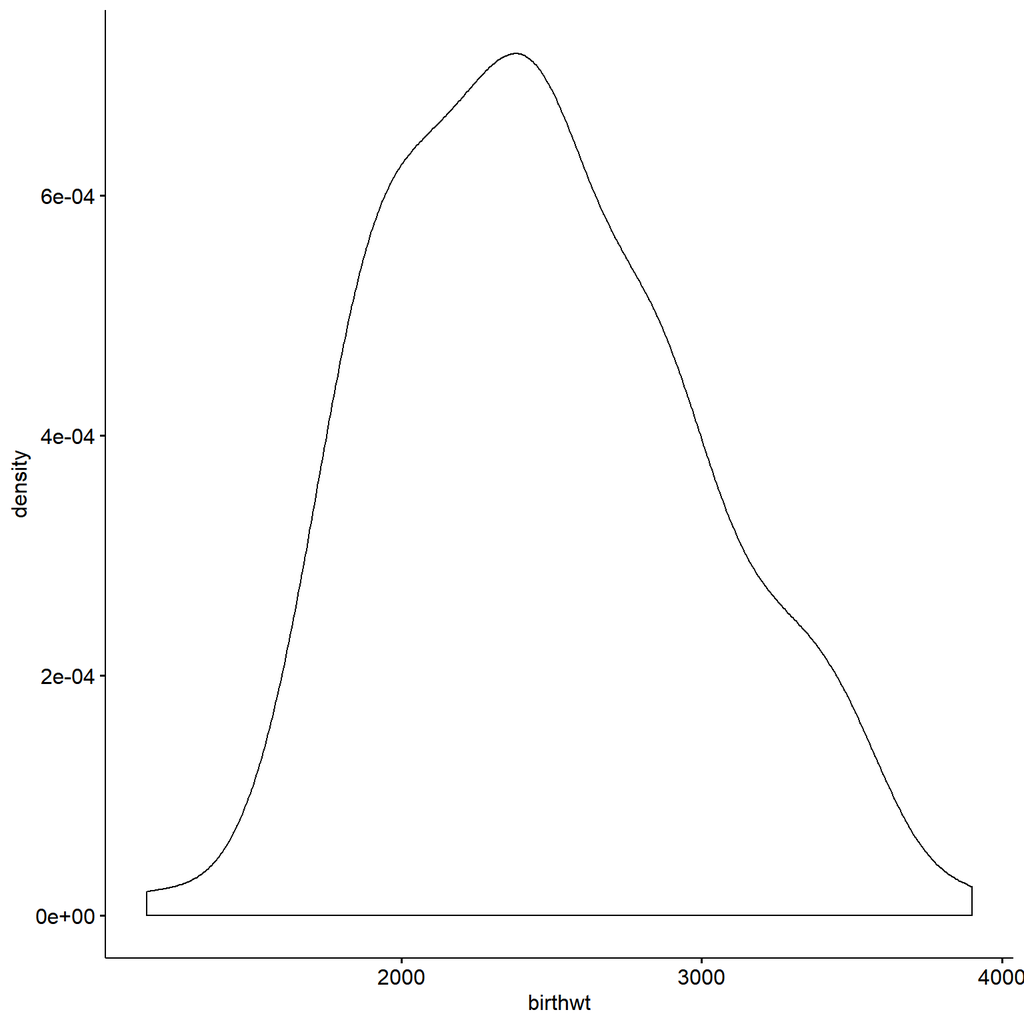

```r
# Basic Density plot
ggdensity(surgery, x = "birthwt")
```

# Sophisticated density plot code

```r
gg <-  ggdensity(surgery, x = "birthwt",add = "median",
            xlab = "Weight at birth (in grams)", ylab = "Frequency",
            title = "Density plot of infant weight at birth",
            fill = "gender",color = "grey",palette = "lancet",
            alpha = 0.2,legend = "bottom",legend.title="Gender",
            font.legend = c(10, "bold", "darkgrey"), facet.by = "infect", ggtheme = theme_minimal() )+
  theme(plot.title = element_text(hjust = 0.5),
        plot.subtitle = element_text(hjust = 0.5))
```

# Sophisticated density plot

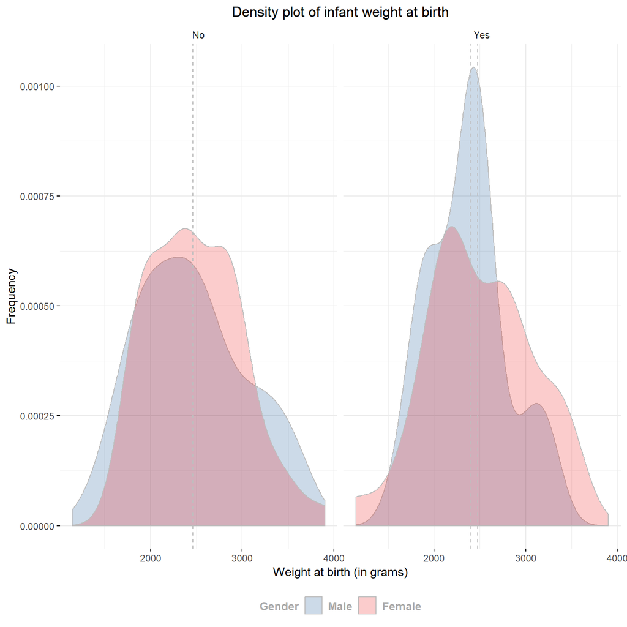

```r
plot(gg)
```

# Scatterplots

What we learned so far?

1. How to use the help file of the gg“function”
2. All the gg functions:
- are compatible with ggpar() function options
- produce ggplot2 objects
- which we can further manipulate using ggplot2 functions
  - such as theme() , facet_grid() etc

# Scatter-plot

Exercise 1: Can we make this plot?

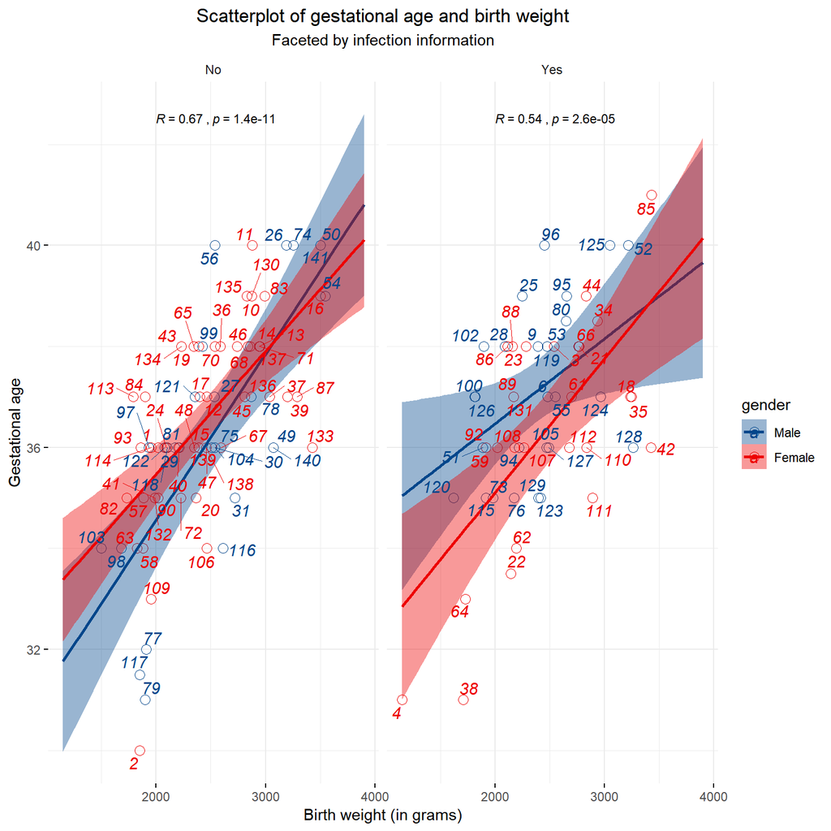

# Remember

We know we want to plot a scatterplot. We use the surgery data

- ggscatter() is the function
- go the help file
- start filling the options

# Simple point-line plot

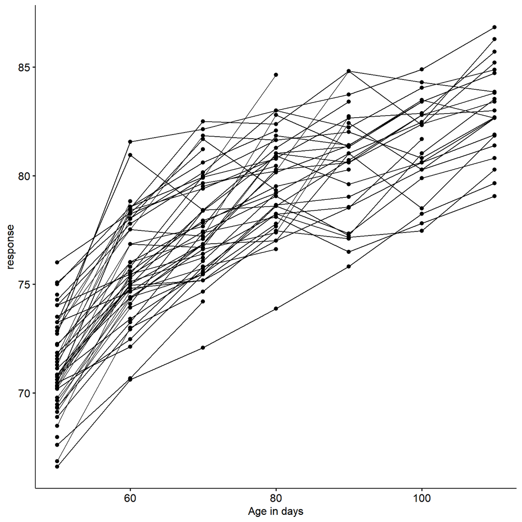